# Laboratorio Recuperativo: Redes Neuronales

Integrantes: **Juan Pablo Bustamante y Tomás Vallejo, Sección 1**

# Instrucciones

1. Trabajen en equipos de dos personas. Salvo excepciones, no se corregirá entregas con menos de dos integrantes.
2. Modifiquen este archivo `.ipynb` agregando sus respuestas donde corresponda.
3. Cuando finalicen el laboratorio, **generen un archivo HTML** usando jupyter (ver tutorial 3) y súbanlo a U-Cursos. El laboratorio debe ser entregado sólo por 1 integrante. Si se entrega por más de un integrante, se revisará cualquiera de éstos.

```python
%pip install scipy scikit-learn numpy pandas torch
```

# **Redes Neuronales con Scikit-learn**

**Objetivo**

En este laboratorio, trabajarán con el dataset Fashion-MNIST para entrenar y evaluar modelos de redes neuronales usando tanto scikit-learn como PyTorch. Aprenderán a explorar datos, entrenar modelos, y analizar sus resultados.

Primero preparamos el dataset y vemos cómo se ven las imágenes.

```
El dataset tiene 5000 ejemplos y 784 características
El dataset tiene 10 clases: ['0' '1' '2' '3' '4' '5' '6' '7' '8' '9']
```

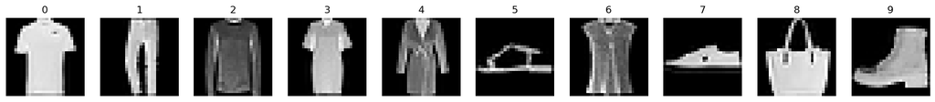

```python
import numpy as np
import matplotlib.pyplot as plt
from sklearn.model_selection import train_test_split
from sklearn.datasets import fetch_openml

# Cargar el dataset Fashion-MNIST
X, y = fetch_openml("Fashion-MNIST", version=1, return_X_y=True, as_frame=False)

# El dataset es muy grande por lo que tomamos solo una muestra
np.random.seed(42)
idx = np.random.choice(len(X), 5000, replace=False)
X = X[idx]
y = y[idx]

n_features = X.shape[1]
n_classes = len(np.unique(y))
print(f"El dataset tiene {X.shape[0]} ejemplos y {n_features} características")
print(f"El dataset tiene {n_classes} clases: {np.unique(y)}")

unique_labels = np.unique(y)


# Normalizar los datos
X = X / 255.0  # Normalizar
y = y.astype(int)  # Asegurar que las etiquetas son enteros

# Dividir el dataset en entrenamiento (70%), validación (15%) y test (15%)
X_train, X_temp, y_train, y_temp = train_test_split(X, y, test_size=0.3, random_state=42)
X_val, X_test, y_val, y_test = train_test_split(X_temp, y_temp, test_size=0.5, random_state=42)

# Mostramos un ejemplo por cada clase
fig, axes = plt.subplots(1, len(unique_labels), figsize=(20, 20))
for i, label in enumerate(unique_labels):
    axes[i].imshow(X_train[y_train == i][0].reshape(28, 28), cmap="gray")
    axes[i].set_title(label)
    axes[i].axis("off")
plt.show()
```

### **Entrenamiento de un MLP con scikit-learn**

**Pregunta 1**

Crea 2 MLPs con sklearn con los siguientes parámetros:

El primero debe tener:

- 3 capas ocultas de 32, 16 y 16 neuronas respectivamente.
- Función de activación ReLU.
- El modelo debe tener un máximo de 300 iteraciones.

y debes guardarlo en la variable `mlp1`.

El segundo debe tener:

- 3 capas ocultas de 64, 32 y 16 neuronas respectivamente.
- Función de activación ReLU.
- El modelo debe tener un máximo de 300 iteraciones.

y debes guardarlo en la variable `mlp2`.

**Recuerda setear un random_state para que los resultados sean reproducibles.**

```python
from sklearn.neural_network import MLPClassifier

# MLP 1: 3 capas ocultas (32, 16, 16), ReLU, 300 iteraciones
mlp1 = MLPClassifier(
    hidden_layer_sizes=(32, 16, 16),
    activation="relu",
    max_iter=300,
    random_state=42)

# MLP 2: 3 capas ocultas (64, 32, 16), ReLU, 300 iteraciones
mlp2 = MLPClassifier(
    hidden_layer_sizes=(64, 32, 16),
    activation="relu",
    max_iter=300,
    random_state=42)
```

**Pregunta 2**

Para cada modelo

- Entrena el MLP
- Evalúa su desempeño en el conjunto de validación mostrando el accuracy.
- Contestar las siguientes preguntas: ¿Qué modelo tiene mejor desempeño en accuracy? ¿A qué crees que se debe esto?
- Crea una variable llamada mlp_best y guarda en ella el mejor modelo.

```python
from sklearn.metrics import accuracy_score

# Entrenamos cada MLP
mlp1.fit(X_train, y_train)
mlp2.fit(X_train, y_train)

# Predicciones en el conjunto de validación
y_val_pred1 = mlp1.predict(X_val)
y_val_pred2 = mlp2.predict(X_val)

# Accuracy en validación
acc1 = accuracy_score(y_val, y_val_pred1)
acc2 = accuracy_score(y_val, y_val_pred2)

print(f"Accuracy de validación MLP1: {acc1:.4f}")
print(f"Accuracy de validación MLP2: {acc2:.4f}")
```

```
Accuracy de validación MLP1: 0.8160
Accuracy de validación MLP2: 0.8320
```

**Respuesta:**

El MLP2 obtuvo un accuracy de validación ligeramente mayor (0.832) comparado con el MLP1 (0.816). Esta diferencia se explica porque MLP2 tiene una arquitectura más grande (64–32–16), lo que le da mayor capacidad de representación y permite que el modelo aprenda patrones más complejos en las imágenes. Como las clases de Fashion-MNIST contienen variabilidad considerable, un modelo con más neuronas suele ajustar mejor las fronteras de decisión sin sobreajustar de manera significativa. Por esta razón, MLP2 presenta un mejor desempeño y se selecciona como mlp_best.

```python
mlp_best = mlp2 if acc2 > acc1 else mlp1
mlp_best
```

```
MLPClassifier(hidden_layer_sizes=(64, 32, 16), max_iter=300, random_state=42)
```

**Pregunta 3**

Para el mejor modelo encontrado en la pregunta anterior (el guardado en la variable `mlp_best`)

- Muestra la matriz de confusión para el conjunto de validación
- Constete: ¿Qué clase se confunden más entre sí? ¿Por qué crees que ocurre esto? Relacionalo con los productos de cada clase que viste anteriormente (mostrado al cargar los datos).

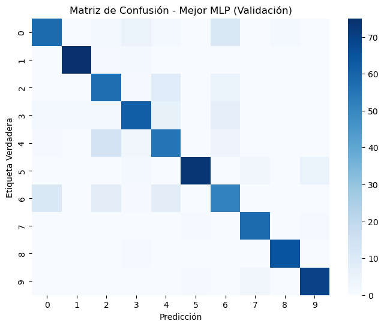

```
array([[58,  0,  2,  5,  2,  0, 11,  0,  2,  0],
       [ 0, 75,  1,  2,  0,  0,  0,  0,  0,  0],
       [ 0,  0, 57,  1,  9,  0,  5,  0,  0,  0],
       [ 2,  2,  2, 62,  6,  0,  7,  0,  0,  0],
       [ 1,  0, 14,  3, 55,  0,  4,  0,  0,  0],
       [ 0,  0,  0,  2,  0, 73,  0,  3,  0,  5],
       [11,  0,  8,  1,  8,  0, 51,  0,  0,  0],
       [ 0,  0,  0,  0,  0,  1,  0, 58,  0,  1],
       [ 0,  0,  0,  1,  0,  0,  0,  0, 65,  0],
       [ 0,  0,  0,  0,  0,  1,  0,  3,  0, 70]])
```

```python
from sklearn.metrics import confusion_matrix
import seaborn as sns

# Predicciones del mejor modelo en validación
y_val_pred_best = mlp_best.predict(X_val)

# Matriz de confusión
cm = confusion_matrix(y_val, y_val_pred_best)

plt.figure(figsize=(8,6))
sns.heatmap(cm, annot=False, cmap="Blues")
plt.title("Matriz de Confusión - Mejor MLP (Validación)")
plt.xlabel("Predicción")
plt.ylabel("Etiqueta Verdadera")
plt.show()

cm
```

**Respuesta**:

A partir de la matriz de confusión se observa que el modelo clasifica correctamente la mayoría de las prendas, algo coherente con el accuracy obtenido. Las confusiones más frecuentes ocurren entre Pullover (2), Coat (4) y Shirt (6), además de algunos errores entre T-shirt/top (0) y Shirt (6). Estas clases son visualmente muy parecidas en las imágenes de 28×28 en escala de grises, por lo que el modelo no logra distinguir detalles finos como cuello, grosor o forma exacta. En cambio, clases con siluetas más distintivas como Sandal, Bag o Ankle Boot presentan menos errores.

### **Entrenamiento de un MLP con PyTorch**

```python
import torch
import torch.nn as nn
from torch.utils.data import DataLoader, TensorDataset
import torch.optim as optim
```

**Pregunta 4**

Convierta los datos al formato de PyTorch para usar los DataLoader

- Transforme los splits de train, val y test a tensores de PyTorch
- Cree Datasets de PyTorch con los tensores creados
- Cree DataLoaders de PyTorch con los Datasets creados con un batch_size de 64

```python
# Convertir los splits a tensores de PyTorch
X_train_tensor = torch.from_numpy(X_train.astype(np.float32))
y_train_tensor = torch.from_numpy(y_train.astype(np.int64))

X_val_tensor   = torch.from_numpy(X_val.astype(np.float32))
y_val_tensor   = torch.from_numpy(y_val.astype(np.int64))

X_test_tensor  = torch.from_numpy(X_test.astype(np.float32))
y_test_tensor  = torch.from_numpy(y_test.astype(np.int64))

# Crear TensorDataset para cada split
train_dataset = TensorDataset(X_train_tensor, y_train_tensor)
val_dataset   = TensorDataset(X_val_tensor, y_val_tensor)
test_dataset  = TensorDataset(X_test_tensor, y_test_tensor)

# Crear DataLoaders con batch_size = 64
batch_size = 64

train_loader = DataLoader(train_dataset, batch_size=batch_size, shuffle=True)
val_loader   = DataLoader(val_dataset, batch_size=batch_size, shuffle=False)
test_loader  = DataLoader(test_dataset, batch_size=batch_size, shuffle=False)
```

**Pregunta 5**

Crea un modelo de MLP con PyTorch con la siguiente arquitectura:

- 1 capa ocultas de 64 neuronas respectivamente.
- Función de activación ReLU.

**Recuerda setear un random_state para que los resultados sean reproducibles.**

**Hint**: Recuerda que la dimensión de input depende de la cantidad de features que tienes, y la dimensión de output depende de la cantidad de clases que tienes.

```python
# Fijamos semilla para reproducibilidad en PyTorch
torch.manual_seed(42)

# Dimensión de entrada y salida
input_size = X_train.shape[1]
num_classes = len(np.unique(y_train))

class MLP(nn.Module):
    def __init__(self, input_size, hidden_size, num_classes):
        super(MLP, self).__init__()
        # Capa oculta de 64 neuronas
        self.fc1 = nn.Linear(input_size, hidden_size)
        self.relu = nn.ReLU()
        # Capa de salida con tantas neuronas como clases
        self.fc2 = nn.Linear(hidden_size, num_classes)

    def forward(self, x):
        x = self.fc1(x)
        x = self.relu(x)
        x = self.fc2(x)
        return x
```

La siguiente función no debes modificarla, la tendrás que usar en la siguiente pregunta.

```python
def train_model(model, train_loader, val_loader, criterion, optimizer, epochs, device='cpu'):
    """
    Función general para entrenar modelos en PyTorch, con seguimiento de pérdidas y métricas.

    Args:
        model: Modelo de PyTorch a entrenar.
        train_loader: DataLoader para los datos de entrenamiento.
        val_loader: DataLoader para los datos de validación.
        criterion: Función de pérdida.
        optimizer: Optimizador para el modelo.
        epochs: Número de épocas a entrenar.
        device: CPU o GPU.

    Returns:
        metrics: Diccionario con las pérdidas y métricas de validación.
    """
    model.to(device)
    train_losses = []
    val_losses = []
    val_accuracies = []

    for epoch in range(epochs):
        # Modo de entrenamiento
        model.train()
        total_train_loss = 0

        for X_batch, y_batch in train_loader:
            X_batch, y_batch = X_batch.to(device), y_batch.to(device)
            optimizer.zero_grad()
            outputs = model(X_batch)
            loss = criterion(outputs, y_batch)
            loss.backward()
            optimizer.step()
            total_train_loss += loss.item()

        # Promediar la pérdida de entrenamiento
        avg_train_loss = total_train_loss / len(train_loader)
        train_losses.append(avg_train_loss)

        # Modo de evaluación
        model.eval()
        total_val_loss = 0
        correct = 0
        total = 0
        with torch.no_grad():
            for X_val_batch, y_val_batch in val_loader:
                X_val_batch, y_val_batch = X_val_batch.to(device), y_val_batch.to(device)
                val_outputs = model(X_val_batch)
                val_loss = criterion(val_outputs, y_val_batch)
                total_val_loss += val_loss.item()

                _, predicted = torch.max(val_outputs, 1)
                correct += (predicted == y_val_batch).sum().item()
                total += y_val_batch.size(0)

        avg_val_loss = total_val_loss / len(val_loader)
        val_losses.append(avg_val_loss)

        val_accuracy = correct / total
        val_accuracies.append(val_accuracy)

        print(f"Epoch {epoch+1}/{epochs}, Training Loss: {avg_train_loss:.4f}, Validation Loss: {avg_val_loss:.4f}, Validation Accuracy: {val_accuracy:.4f}")

    # Graficar las pérdidas
    plt.figure(figsize=(10, 6))
    plt.plot(range(1, epochs+1), train_losses, label='Training Loss')
    plt.plot(range(1, epochs+1), val_losses, label='Validation Loss', linestyle='--')
    plt.xlabel('Epochs')
    plt.ylabel('Loss')
    plt.title('Loss Evolution During Training')
    plt.legend()
    plt.grid()
    plt.show()

    return {'train_loss': train_losses, 'val_loss': val_losses, 'val_accuracy': val_accuracies}
```

**Pregunta 6**

Primero, guarda el modelo creado en la variable `mlp_torch`.

Usa la función `train_model` para entrenar tu modelo con los siguientes parámetros:

- `model`: tu modelo de MLP de PyTorch
- `train_loader`: tu DataLoader de entrenamiento
- `val_loader`: tu DataLoader de validación
- `criterion` (la función de pérdida): Usa `nn.CrossEntropyLoss()`
- `optimizer` (el optimizador): : Usa `optim.Adam(mlp_torch.parameters(), lr=0.001)`
- `epochs`: 30

y contesta: ¿por qué la loss de entrenamiento es menor que la loss de validación?

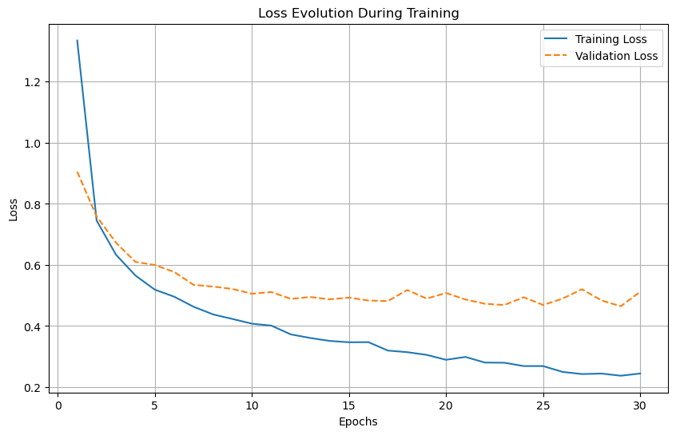

```python
# Creamos el modelo
mlp_torch = MLP(input_size=input_size, hidden_size=64, num_classes=num_classes)

# Optimizador y loss
optimizer = optim.Adam(mlp_torch.parameters(), lr=0.001)
criterion = nn.CrossEntropyLoss()

# Entrenamiento del modelo
metrics = train_model(
    model=mlp_torch,
    train_loader=train_loader,
    val_loader=val_loader,
    criterion=criterion,
    optimizer=optimizer,
    epochs=30,
    device='cpu')
```

**Respuesta**:

La loss de entrenamiento es menor que la de validación porque el modelo ajusta sus pesos directamente sobre los datos de entrenamiento, que ve muchas veces a lo largo de los epochs, por lo que aprende a reducir cada vez más su error en ellos. En cambio, la validación se calcula con datos que el modelo no ha visto antes, por lo que su desempeño es naturalmente peor. Esta diferencia es normal: muestra que el modelo aprende los patrones del entrenamiento, pero sigue generalizando razonablemente bien sin memorizar completamente los datos.

La siguiente función no debes modificarla, la tendrás que usar en la siguiente pregunta.

```python
# Evaluar el modelo en el conjunto de prueba
def evaluate_model(model, data_loader, criterion, device='cpu'):
    model.eval()
    model.to(device)
    data_loss = 0
    correct = 0
    total = 0

    with torch.no_grad():
        for X_batch, y_batch in data_loader:
            X_batch, y_batch = X_batch.to(device), y_batch.to(device)
            outputs = model(X_batch)
            loss = criterion(outputs, y_batch)
            data_loss += loss.item()

            _, predicted = torch.max(outputs, 1)
            correct += (predicted == y_batch).sum().item()
            total += y_batch.size(0)

    accuracy = correct / total
    print(f"Data Accuracy: {accuracy:.4f}")

    avg_loss = data_loss / len(data_loader)
    print(f"Data Loss: {avg_loss:.4f}")

    return {'loss': avg_loss, 'accuracy': accuracy}
```

**Pregunta 7**

Usa la función `evaluate_model` para evaluar tu modelo en los conjuntos de entrenamiento, validación y test.

Muestra la loss y el accuracy para cada conjunto y contesta: ¿Qué conjunto tiene el mejor desempeño? ¿Por qué crees que es así?

La función recibe los siguientes parámetros:

- `model`: tu modelo de MLP de PyTorch
- `data_loader`: el dataloader de los datos que quieres evaluar
- `criterion` (la función de pérdida): Usa `nn.CrossEntropyLoss()`

y retorna la loss y el accuracy.

```python
criterion = nn.CrossEntropyLoss()

# Evaluación en train, val y test
print("Evaluación en TRAIN:")
train_metrics = evaluate_model(mlp_torch, train_loader, criterion)

print("\nEvaluación en VALIDACIÓN:")
val_metrics = evaluate_model(mlp_torch, val_loader, criterion)

print("\nEvaluación en TEST:")
test_metrics = evaluate_model(mlp_torch, test_loader, criterion)
```

```
Evaluación en TRAIN:
Data Accuracy: 0.9211
Data Loss: 0.2326

Evaluación en VALIDACIÓN:
Data Accuracy: 0.8187
Data Loss: 0.5122

Evaluación en TEST:
Data Accuracy: 0.8200
Data Loss: 0.5260
```

**Respuesta**:

La diferencia entre train y val/test indica un ligero overfitting, ya que el modelo aprende algunos patrones específicos del conjunto de entrenamiento que no se transfieren completamente a datos nuevos. Sin embargo, el nivel de overfitting es esperable y no es severo, dado que validación y test mantienen un rendimiento estable y relativamente alto.